# Proyecto 01

#### Estudiante: Niccolo Antonio Zúñiga Bogarín C08690.

# Preparacion de la ruta y los datos.

#### Seleccionamos el directorio donde queremos ubicar la ruta donde guardaremos todos los datos y el proyecto.

```r
setwd("C:/Users/Admin/Desktop/UCR/Procesamiento Geo/Proyecto/Proyecto1")
```

#### Seleccionamos nuestro documento de entrada, selecionamos los separadores y el dec para no tener problemas con el documento de datos.

```r
inp <- read.csv("liberia_datos_climaticos.csv",sep = ",", na.strings = "", dec =",")
```

#### Verificamos los datos y como en este caso hay que eliminar los datos en blanco usamos el comando na.omit.

```r
inp[!complete.cases(inp),]
```

```
##           Date Temperatura..Celsius. HumedadRelativa.... VelocidadViento..m.s.
## 1106 10/1/2018                 25.88               73.79                    NA
## 1107 11/1/2018                 25.30               79.79                    NA
## 1108 12/1/2018                 26.71               75.96                    NA
## 1146 19/2/2018                 28.14               59.67                    NA
## 1147 20/2/2018                 27.55               61.50                    NA
## 1164  9/3/2018                 28.51               62.29                    NA
## 1165 10/3/2018                 29.20               62.08                    NA
## 1166 11/3/2018                 28.60               64.00                    NA
## 1167 12/3/2018                 27.96               67.67                    NA
## 1168 13/3/2018                 28.51               65.13                    NA
## 1169 14/3/2018                 29.34               60.67                    NA
## 1170 15/3/2018                 28.98               58.96                    NA
## 1171 16/3/2018                 29.02               56.67                    NA
## 1193  7/4/2018                    NA                  NA                    NA
```

[output cut: 37 more lines]

```r
inp3 <- na.omit(inp)
inp3[!complete.cases(inp3),]
```

```
## [1] Date                    Temperatura..Celsius.   HumedadRelativa....
## [4] VelocidadViento..m.s.   Lluvia..mm.             Irradiacion..W.m2.
## [7] EvapoTranspiracion..mm.
## <0 rows> (or 0-length row.names)
```

#### Como se puede observar quedó listo para continuar.

# Carga de las bibliotecas

#### Cargamos las bibliotecas, que necesitamos para trabajar con los datos y en relacion con que haremos en este caso los siguintes:

### Carga de dplyr

```r
library(dplyr)
```

### Carga de ggplot2

```r
library(ggplot2)
```

### Carga de hrbrthemes (temas adicionales para ggplot2)

```r
library(hrbrthemes)
```

### Carga de Grid.Extra

```r
library(gridExtra)
```

# Conversion de los datos.

#### Para convertir las variables a numeros usamos el comando as.numeric porque los datos que tienen formato de caracter no nos permite trabajar, entonces los vamos a cambiar a el formato que necesitamos.

```r
inp3$Temperatura..Celsius. <- as.numeric(inp3$Temperatura..Celsius.)
inp3$HumedadRelativa.... <- as.numeric(inp3$HumedadRelativa....)
inp3$VelocidadViento..m.s. <- as.numeric(inp3$VelocidadViento..m.s.)
inp3$Irradiacion..W.m2. <- as.numeric(inp3$Irradiacion..W.m2.)
inp3$EvapoTranspiracion..mm. <-
  as.numeric(inp3$EvapoTranspiracion..mm.)
```

# Renombrar las variables.

#### Para trabajar de una manera mas ordenada vamos a asignar un nombre más accesible a las variables que tengan nombres muy extensos.

```r
inp4 <- inp3 %>%
rename(
Temperatura = Temperatura..Celsius.,
Humedad = HumedadRelativa....,
Velocidad = VelocidadViento..m.s.,
Lluvia = Lluvia..mm.,
Irradiacion = Irradiacion..W.m2.,
Evapotraspiracion = EvapoTranspiracion..mm.
)
```

# Histograma

#### Histograma con las 6 variables e intervalos apropiados, ejes con nombre e unidades en un solo gráfico.

##### Creamos los Histogramas por aparte cada uno como un nuevo DATA con sus respectivos ejes con nombres y unidades.

```r
Temp <- ggplot(inp4, aes(x = Temperatura)) +
  geom_histogram(color = "blue",
                 binwidth = 1,
                 fill = "gray") +
  ggtitle("Temperatura") +
  ylab("Recuento") +
  facet_grid()

Humd <- ggplot(inp4, aes(x = Humedad)) +
  geom_histogram(color = "green",
                 binwidth = 1,
                 fill = "gray") +
  ggtitle("Humedad Relativa") +
  ylab("mm") +
  facet_grid()

VelV <- ggplot(inp4, aes(x = Velocidad)) +
  geom_histogram(color = "purple",
                 binwidth = 1,
                 fill = "gray") +
  ggtitle("Velocidad del viento") +
  ylab("m.s") +
  facet_grid()

Irrad <- ggplot(inp4, aes(x = Irradiacion)) +
  geom_histogram(color = "orange",
                 binwidth = 1,
                 fill = "gray") +
  ggtitle("Irradiacion") +
  ylab("W.m2") +
  facet_grid()

Evapt <- ggplot(inp4, aes(x = Evapotraspiracion)) +
  geom_histogram(color = "red",
                 binwidth = 1,
                 fill = "gray") +
  ggtitle("Evotraspiracion") +
  ylab("mm") +
  facet_grid()

Llvi <- ggplot(inp4, aes(x = Lluvia)) +
  geom_histogram(color = "Brown",
                 binwidth = 1,
                 fill = "gray") +
  ggtitle("LLuvia") +
  ylab("mm") +
  facet_grid()
```

#### Con el comando grid.arrange unimos los DATA para ver histogramas juntos.

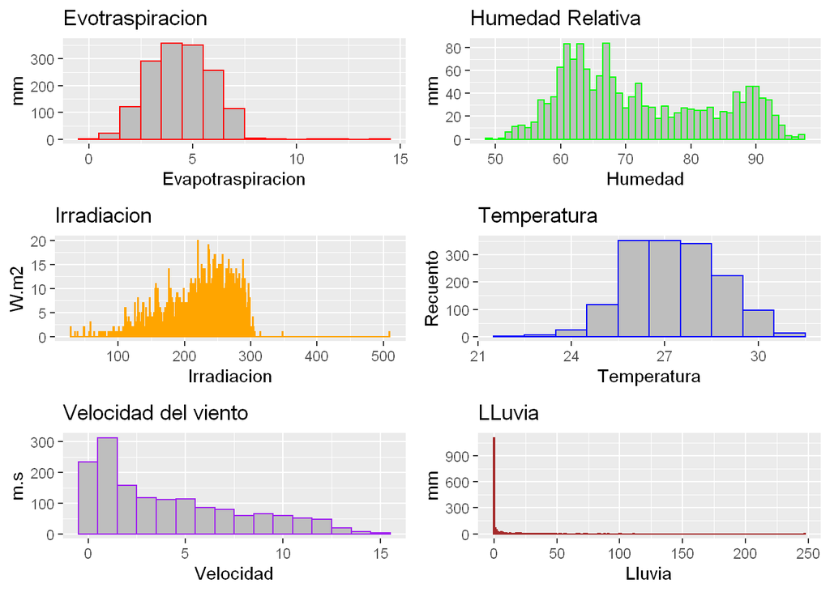

```r
grid.arrange(Evapt, Humd, Irrad, Temp, VelV, Llvi)
```

# Grafico de lineas

#### Establecemos el formato de la fecha, luego los promedios y las sumas, para luego hacer los graficos de lineas como un DATA cada uno.

## Formato de fecha, promedio y suma.

```r
Promedio_mensual <- inp4 %>%
  select(Date,
         Humedad,
         Lluvia,
         Irradiacion,
         Velocidad,
         Evapotraspiracion,
         Temperatura) %>%
  mutate(Date = as.Date(Date, format = "%d/%m/%y")) %>%
  group_by(Date = format(Date,"%m")) %>%
  summarise(
    Humedad = mean(Humedad),
    Velocidad = mean(Velocidad),
    Lluvia = sum(Lluvia),
    Irradiacion = mean(Irradiacion),
    Evapotraspiracion = sum(Evapotraspiracion),
    Temperatura = mean(Temperatura)
  )
```

## Los graficos de lineas como DATA

```r
Pm_Temp <-
  ggplot(Promedio_mensual, aes(x = Date, y = Temperatura, group = 1)) +
  ggtitle("Promedio de Temperatura") +
  ylab("℃") +
  xlab("Mensual") + geom_line()

Pm_Hum <-
  ggplot(Promedio_mensual, aes(x = Date, y = Humedad, group = 1)) +
  ggtitle("Promedio de Humedad Relativa ") +
  ylab("Humedad") +
  xlab("Mensual") + geom_line()

Pm_Velv <-
  ggplot(Promedio_mensual, aes(x = Date, y = Velocidad, group = 1)) +
  ggtitle("Promedio de Velocidad del Viento ") +
  ylab("m.s") +
  xlab("Mensual") + geom_line()

Pm_Irad <-
  ggplot(Promedio_mensual, aes(x = Date, y = Irradiacion, group = 1)) +
  ggtitle("Promedio de Irradiacion") +
  ylab("W.m2") +
  xlab("Mensual") + geom_line()

Sm_Lluvia <-
  ggplot(Promedio_mensual, aes(x = Date, y = Lluvia, group = 1)) +
  ggtitle("Suma de la Lluvua") +
  ylab("mm") +
  xlab("Suma") + geom_line()

Sm_EvapT <-
  ggplot(Promedio_mensual, aes(x = Date, y = Evapotraspiracion, group = 1)) +
  ggtitle("Suma de la Evapotraspiracion") +
  ylab("mm") +
  xlab("Suma") + geom_line()
```

#### Utilizamos el comando Grid.arrange para unir los DATAS y visualizar los graficos juntos.

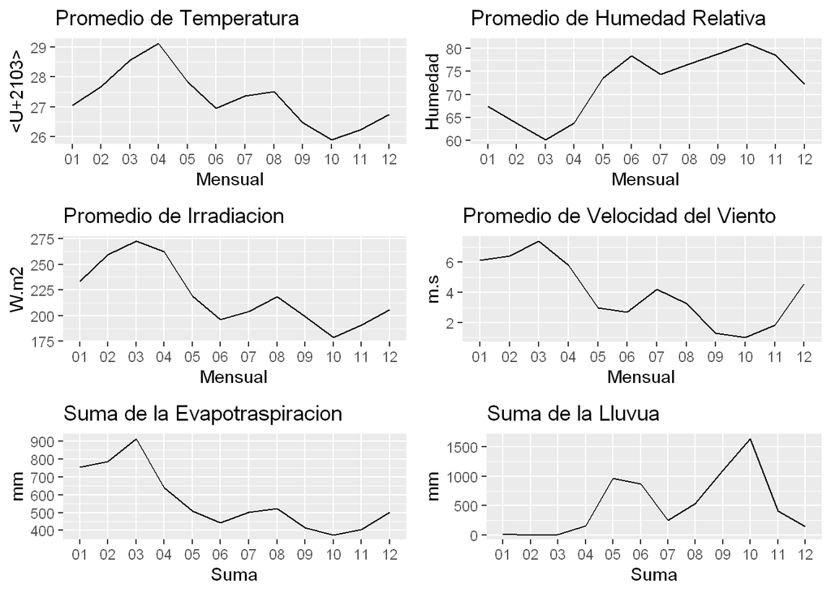

```r
grid.arrange(Pm_Temp,Pm_Hum,Pm_Irad,Pm_Velv, Sm_EvapT, Sm_Lluvia)
```

# Graficos de nube de puntos

#### Hacemos los graficos individuales y les asignamos un nombre para crear un DATA para cada uno con las caracteristicas que necesitamos

## Graficos como DATAS

```r
Gnp_EvapT <- ggplot(inp4, aes(x = Date, y = Evapotraspiracion, group = 1)) +
  geom_point(color = "red") +
  ylab("mm") +
  xlab("Evapotranspiracion")

Gnp_Lluvia <- ggplot(inp4, aes(x = Date, y = Lluvia, group = 1)) +
  geom_point(color = "Brown") +
  ylab("mm") +
  xlab("Lluvia")

Gnp_Irad <- ggplot(inp4, aes(x = Date, y = Irradiacion, group = 1)) +
  geom_point(color = "orange") +
  ylab("W.m2") +
  xlab("Irradiacion")

Gnp_Velv <- ggplot(inp4, aes(x = Date, y = Velocidad, group = 1)) +
  geom_point(color = "purple") +
  ylab("m.s") +
  xlab("Velocidad del viento")

Gnp_Hum <- ggplot(inp4, aes(x = Date, y = Humedad, group = 1)) +
  geom_point(color = "green") +
  ylab("mm") +
  xlab("Humedad Relativa")

Gnp_Temp <- ggplot(inp4, aes(x = Date, y = Temperatura, group = 1)) +
  geom_point(color = "blue") +
  ylab("℃") +
  xlab("Temperatura en ℃")
```

#### Utilizamos el comando Grid.arrange para unir los DATAS y visualizar los graficos juntos.

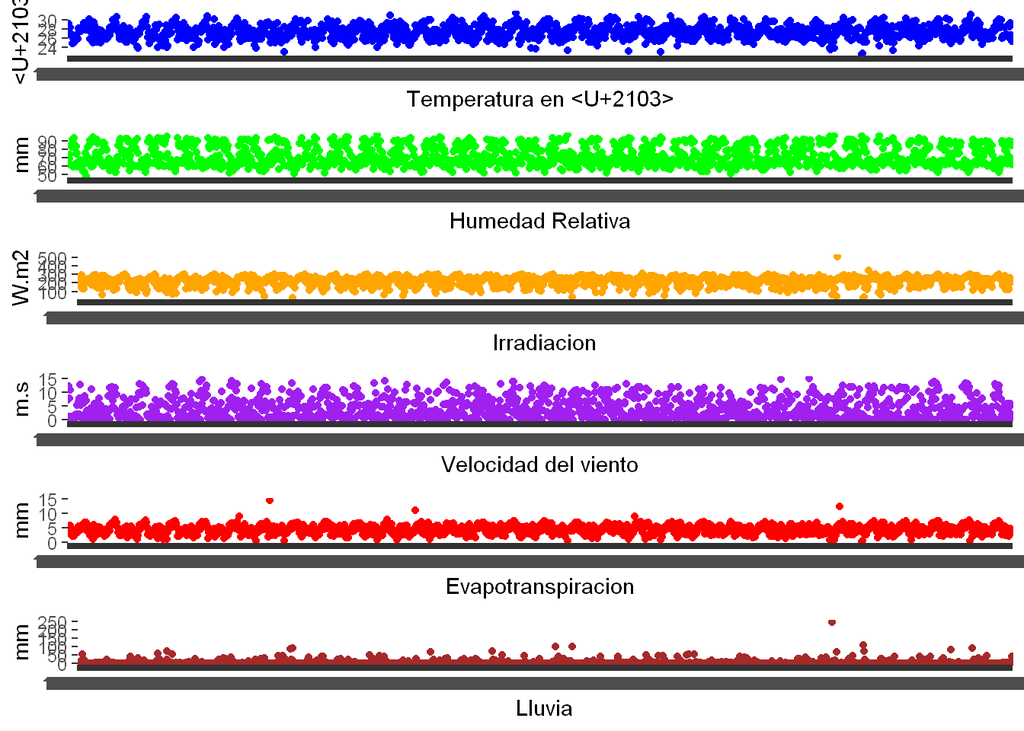

```r
grid.arrange(Gnp_Temp, Gnp_Hum, Gnp_Irad, Gnp_Velv, Gnp_EvapT, Gnp_Lluvia, nrow = 6, ncol = 1)
```